# Model-based evaluation of influenza vaccination outcomes

[andreashandel.com/presentations](https://www.andreashandel.com/presentations/)

[Andreas Handel](https://www.andreashandel.com)

2026-09-08

## Talk Overview

- **Part 1**  
  Heterologous immunogenicity of high-dose (HD) influenza vaccines
- **Part 2**  
  Estimating improved protection of HD vaccines
- **Part 3**  
  The role of prior immunity on immunogenicity
- **Part 4**  
  Software, courses and other resources

## Overall Motivation

- Influenza vaccines work, but could be better.
- Older individuals often don’t respond well to vaccines.
- Influenza virus keeps evolving (strain mismatch).
- Pre-existing immunity often leads to poor induction of immune responses.

*A better understanding of existing vaccines can help design better future ones.*

# Part 1: Heterologous immunogenicity of high-dose (HD) vaccines

[Billings et al 2025 JID](https://doi.org/10.1093/infdis/jiaf003)

## The impact of dose for influenza vaccination

- One of the currently available enhanced vaccines is Fluzone High-Dose (HD).
- The HD vaccine protect(ed) better compared to the standard dose (SD) vaccine against matching strains.
- How broad is this protection if strains are mis-matched?

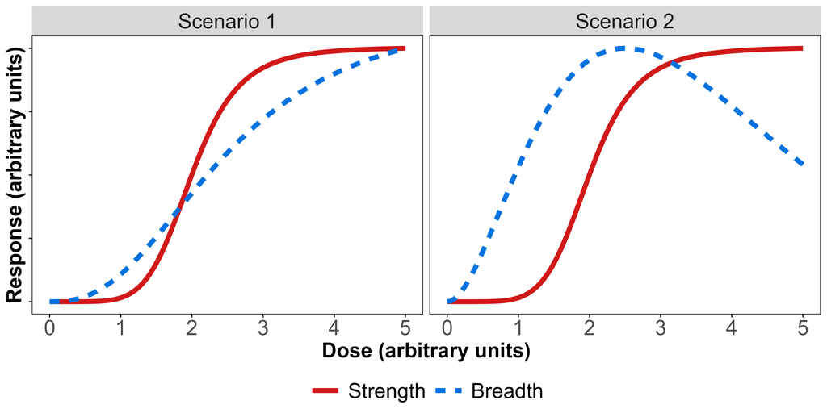

## The data

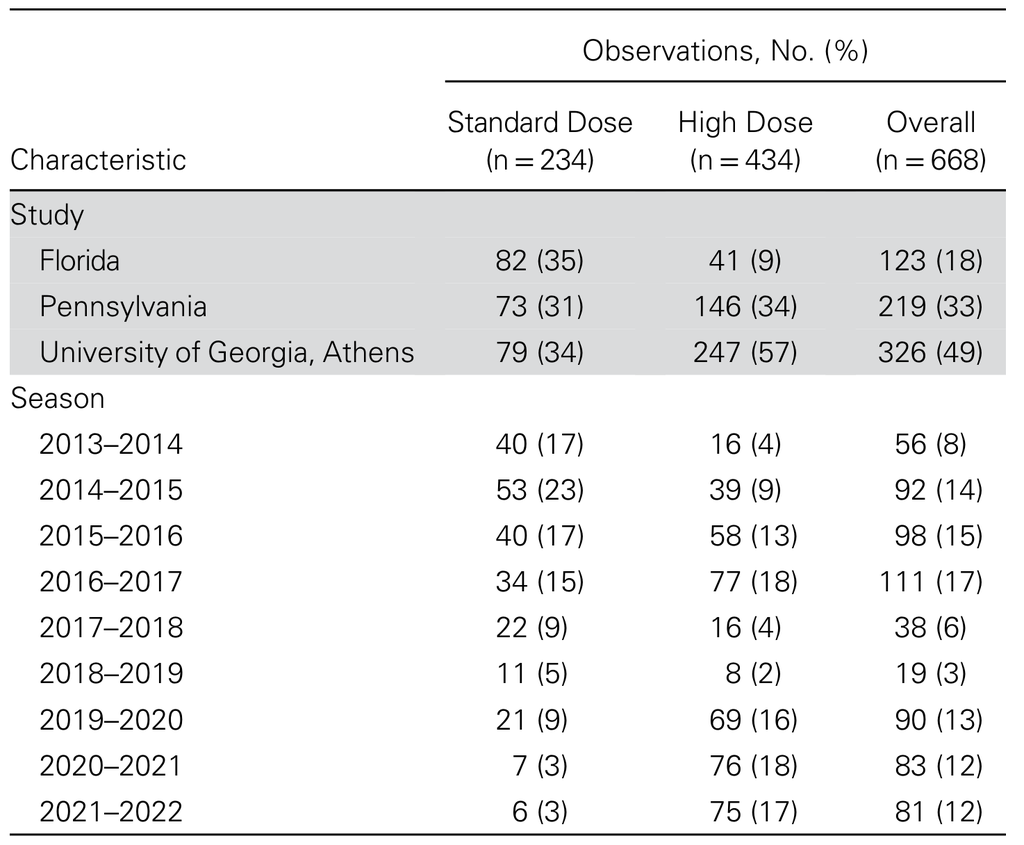

Immunogenicity (antibody) data from a large vaccination cohort. All individuals ≥65y.

## Vaccine Strains

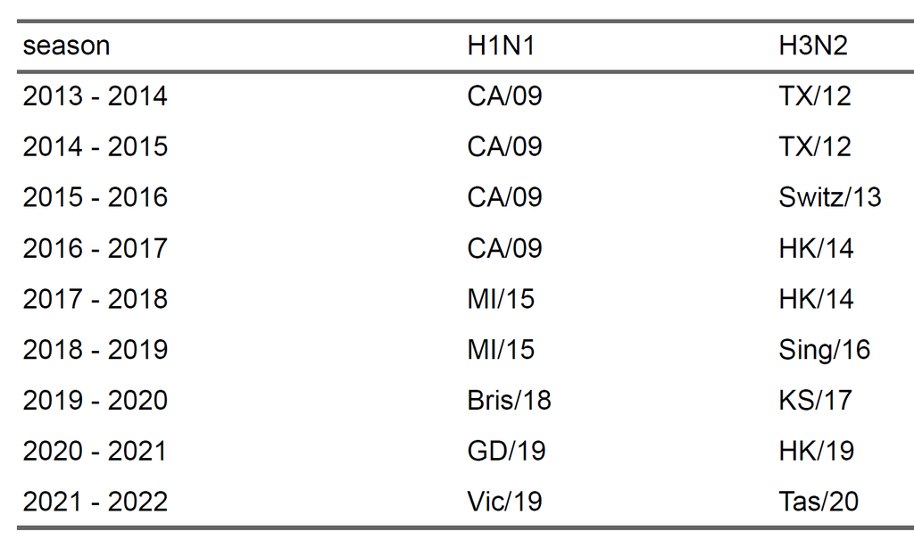

## “Raw” data — homologous responses

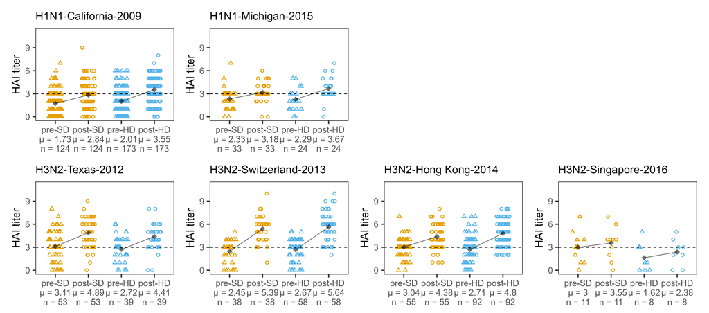

## “Raw” data — heterologous responses

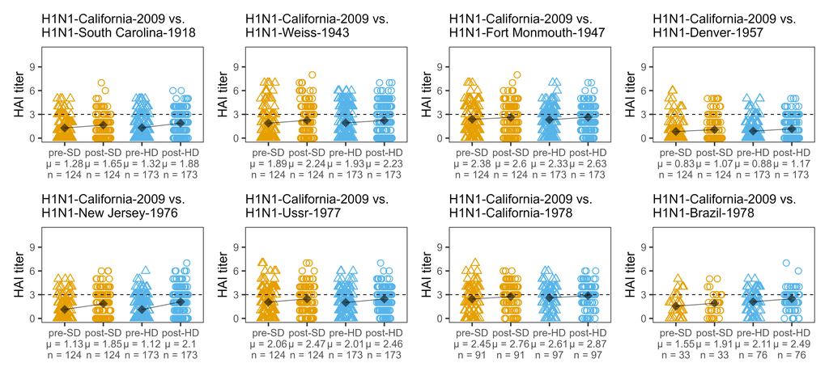

## The model (`brms` code)

Bayesian, hierarchical model. Nesting of strains/individuals/seasons.

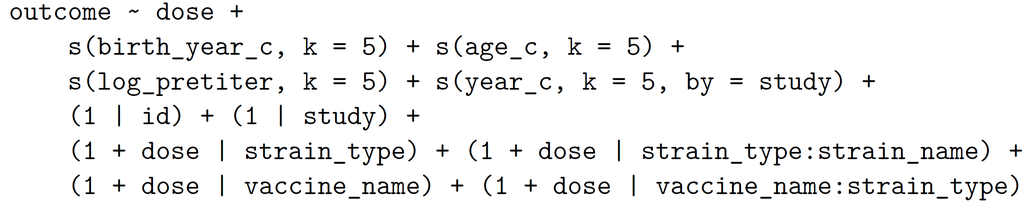

See paper supplement for all the math.

## H1N1 antibodies after HD/SD vaccine

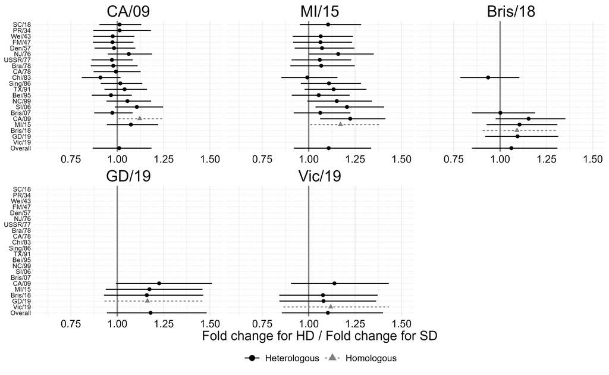

## H3N2 antibodies after HD/SD vaccine

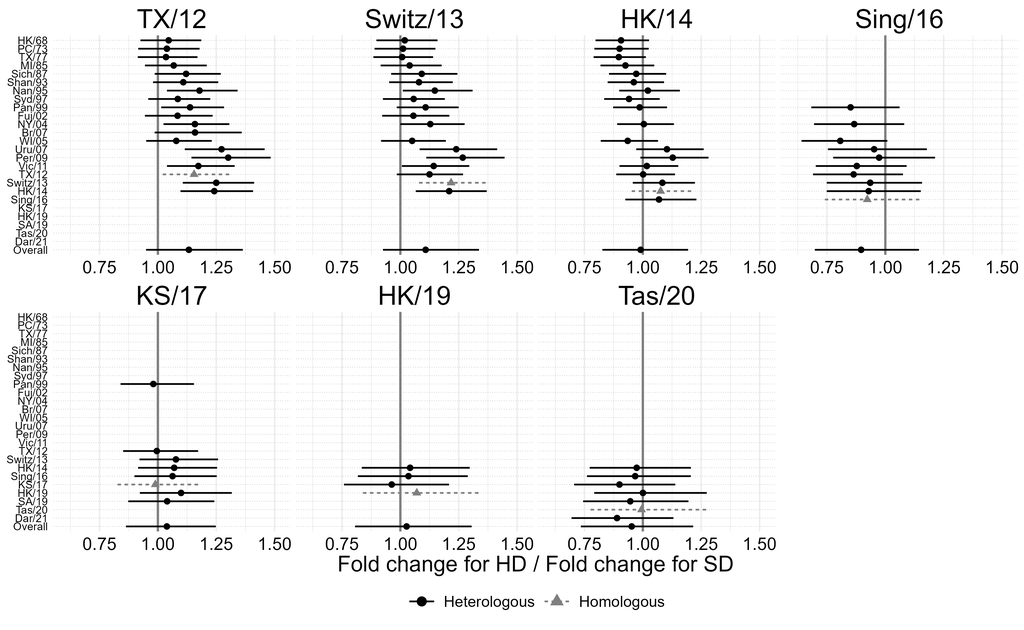

## Overall response

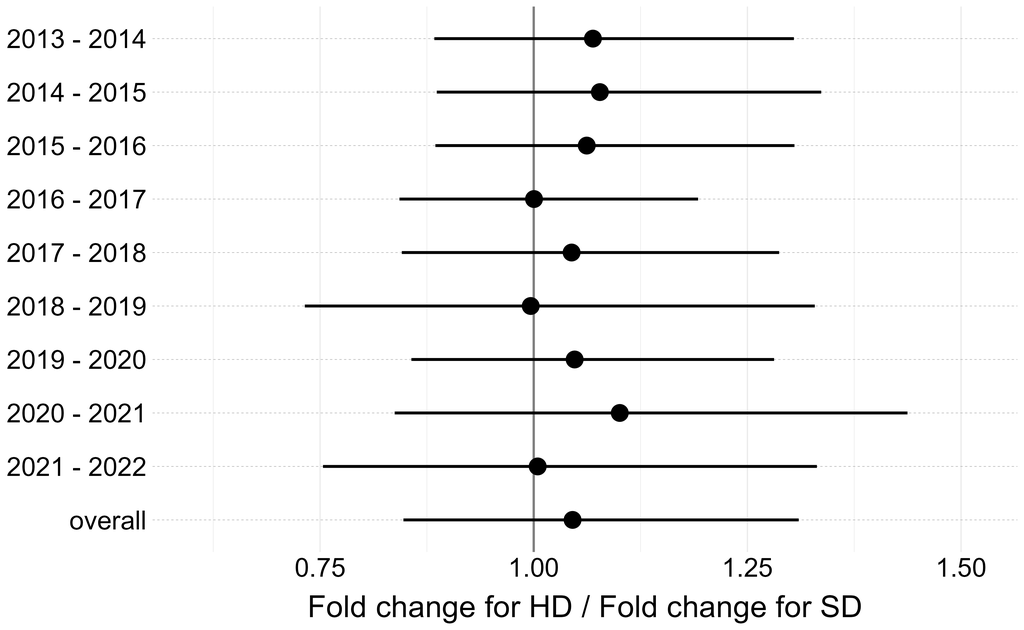

Summing across all strains and subtypes.

## Part 1 Summary

- Overall, the HD vaccine seems to induce a somewhat better response compared to the SD vaccine.
- The effect is not strong, and varies by vaccine strain/season.
- It might be worth further tweaking/increasing the dose.

# Part 2: Estimating improved protection of HD vaccines

[Hammerton et al 2025 JID](https://doi.org/10.1093/infdis/jiae615)

## Introduction

- In 2011-13, HD vaccine showed better protection compared to standard dose (SD).
- Strains are being updated each year, we don’t know if HD is still better.
- How do different antibody levels map to protection?

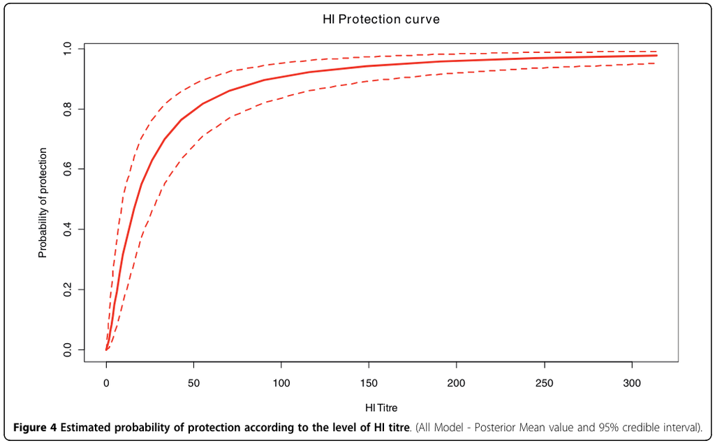

Coudeville et al, 2010 BMC Med Res Methodol

## Approach Overview (1/2)

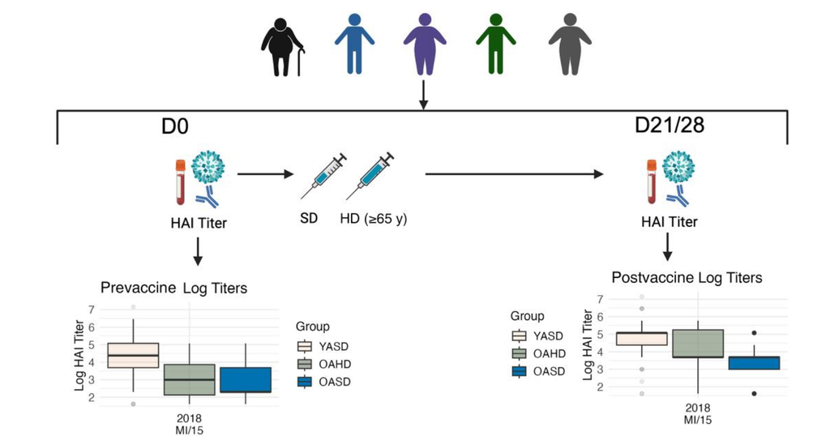

## Approach Overview (2/2)

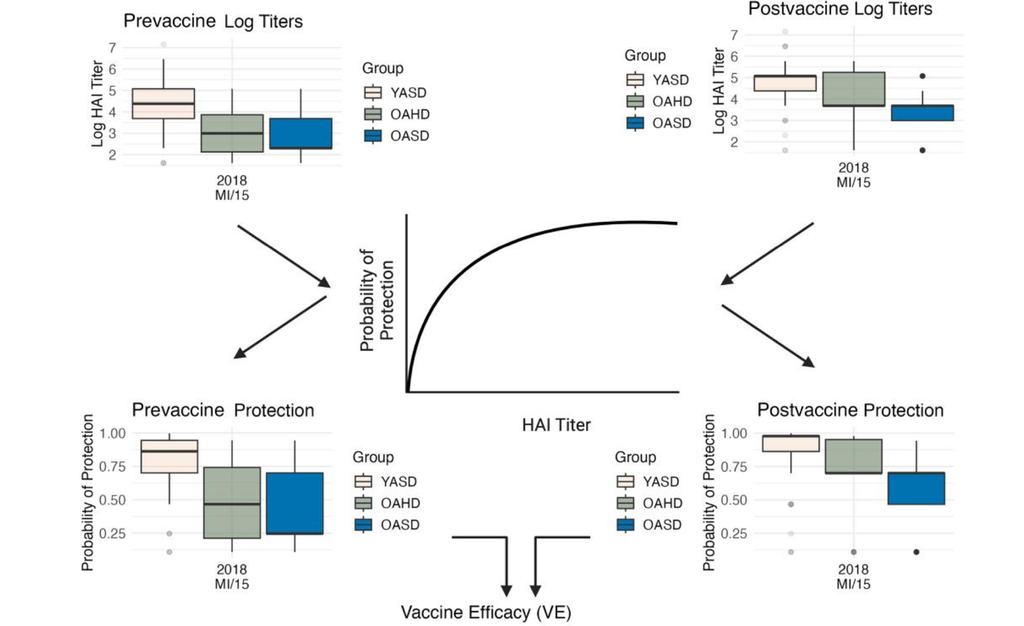

## VE Estimates

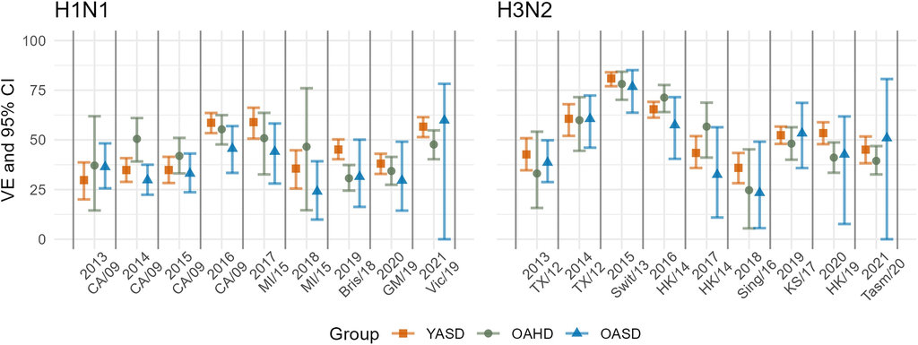

## VE Comparisons: OASD vs. YASD

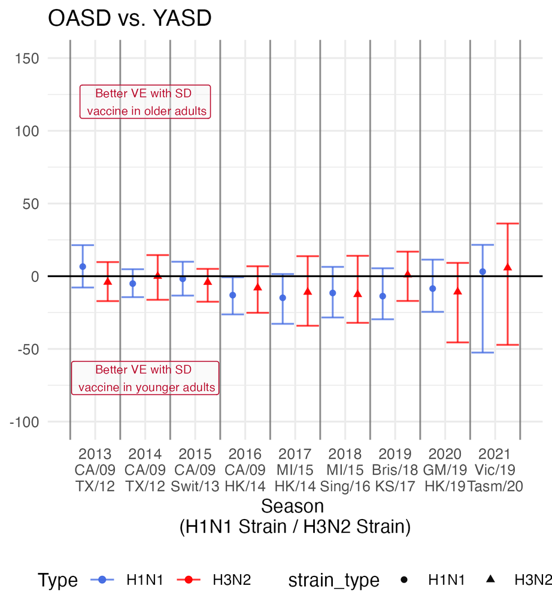

## VE Comparisons: OAHD vs. YASD

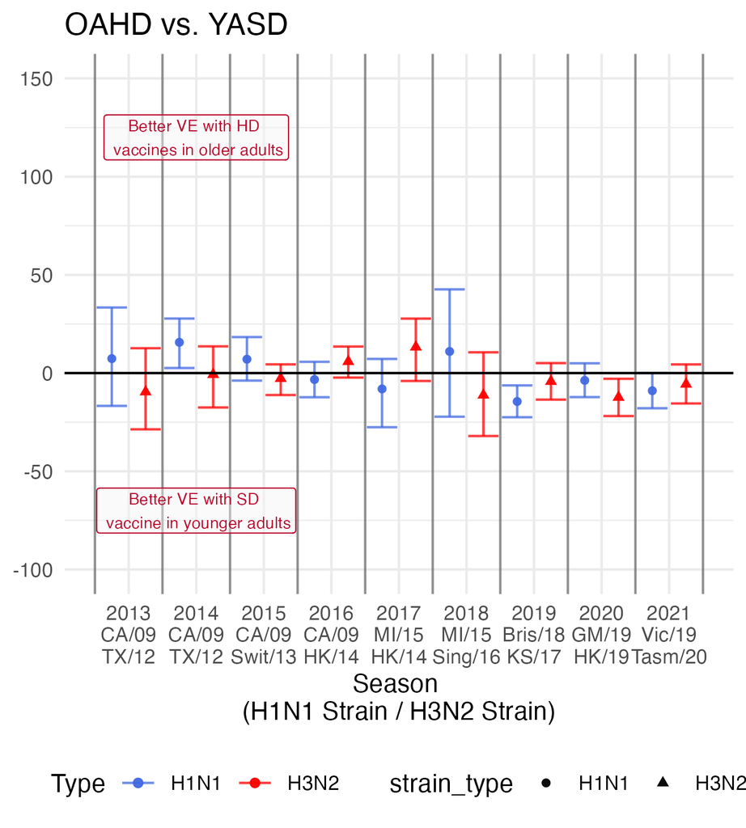

## VE Comparisons: OAHD vs. OASD

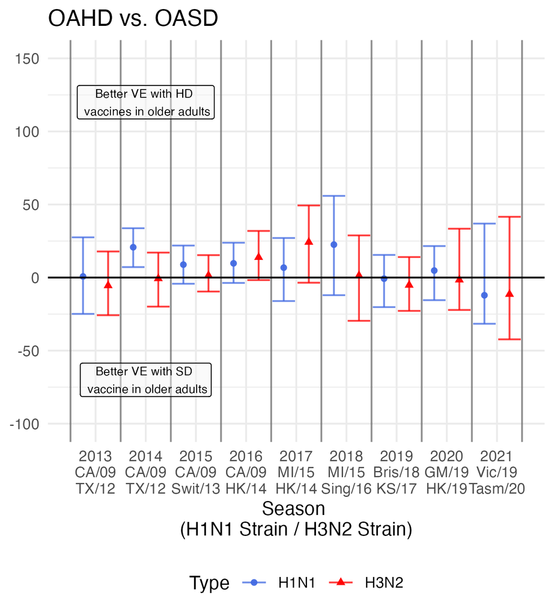

## Part 2 Summary

- The HD vaccine is predicted to improve protection somewhat compared to the SD vaccine.
- The effect is not strong, and varies by vaccine strain/season.
- It might be worth further tweaking/increasing the dose or giving HD to all ages.

# Part 3: The role of prior immunity on immunogenicity

## Introduction

- Influenza vaccines are given in the context of prior immunity.
- Pre-existing antibodies have been associated with lower response (ceiling effect, response blunting).
- (Almost) all models of antibody vaccine responses include pre-existing antibodies in a linear model.

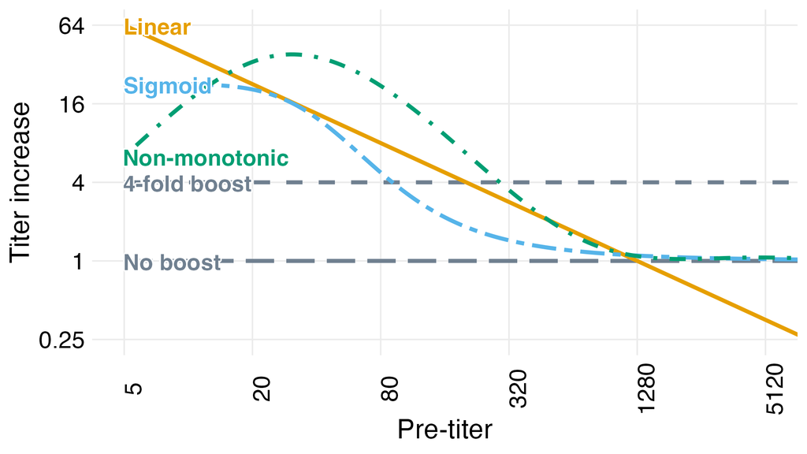

## Data

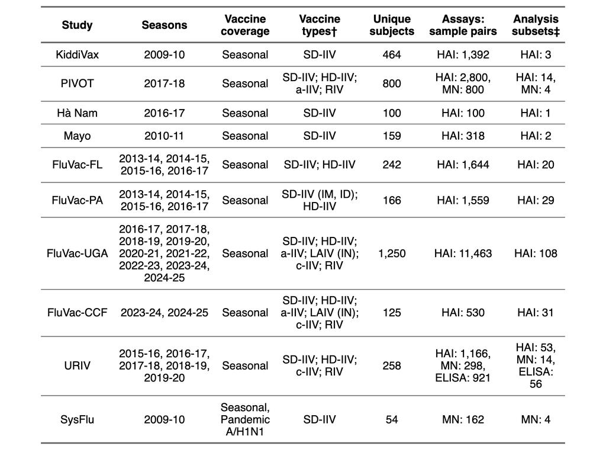

## Models

- Fit linear, sigmoid and spline models to each subset (season/strain/vaccine).
- Compare quality of fits with cross-validated RMSE.
- Perform (Bayesian) resampling to obtain distributions and uncertainty estimates.

## Individual Results Example

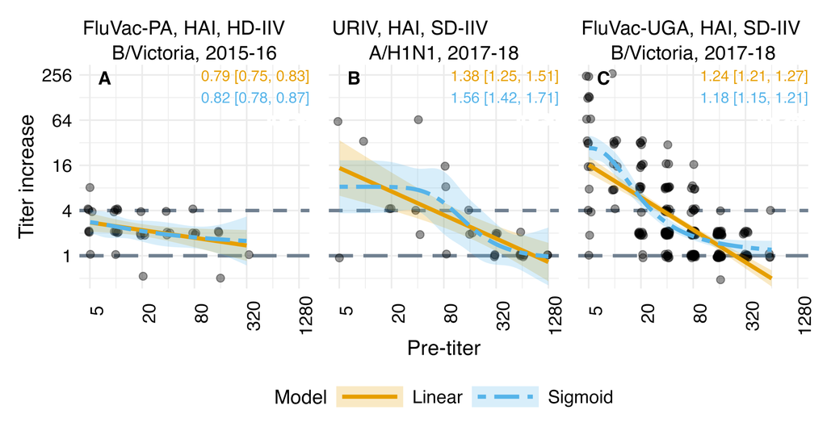

## Resampling Schematic

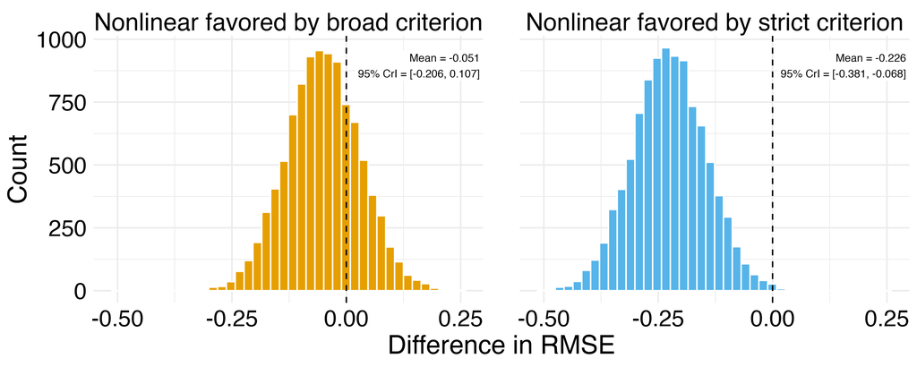

## HAI Results

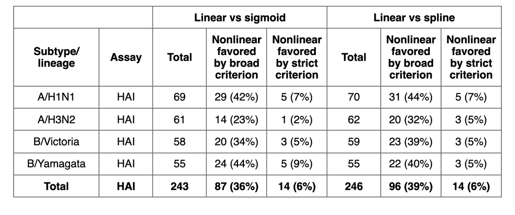

## MN and ELISA Results

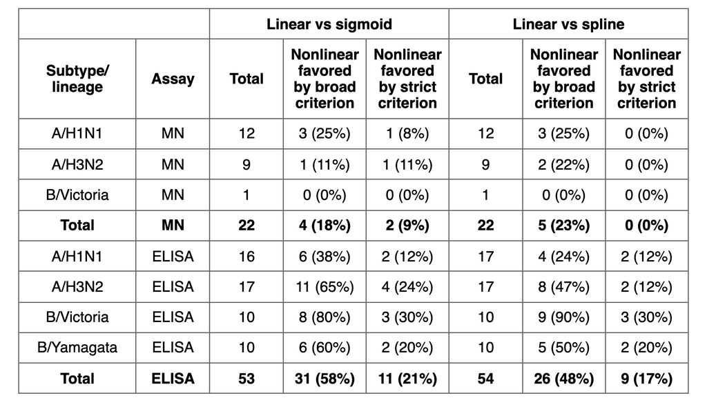

## Part 3 Summary

- Linear models seem to be sufficient in most cases.
- Disentangling statistical effects from a real signal requires further investigation.
- More details: github.com/ahgroup/hemme-pare-public

# Part 4: Software, courses and other resources

[figure not shown]

Jorge Cham · phdcomics.com

## R packages

[figure not shown]

- **[DSAIRM](https://ahgroup.github.io/DSAIRM/)** teaching · stable  
  Dynamical Systems Approach to Immune Response Modeling — teaches modeling for within-host infection and immunology.

[figure not shown]

- **[DSAIDE](https://ahgroup.github.io/DSAIDE/)** teaching · stable  
  Dynamical Systems Approach to Infectious Disease Epidemiology (Ecology/Evolution) — teaches model-based infectious disease epidemiology in a user-friendly way.

[figure not shown]

- **[modelbuilder](https://ahgroup.github.io/modelbuilder/)** research · less stable  
  Build and analyze simulation models without the need to write code.

[figure not shown]

- **[flowdiagramr](https://ahgroup.github.io/flowdiagramr/)** research · less stable  
  Easy creation of high-quality flow diagrams.

## Courses

[figure not shown]

- **[Modern Applied Data Analysis](https://andreashandel.github.io/MADAcourse/)** course  
  Complete materials of an online course on modern applied data analysis.

[figure not shown]

- **[Modeling and Data Science Tools](https://andreashandel.github.io/mds-tools/)** mini-courses  
  Mini-courses and tutorials covering tools for modeling and data science.

[figure not shown]

- **[Infectious Disease Epidemiology](https://andreashandel.github.io/IDEMAcourse/)** course  
  (Ecology)(Evolution) — a model-based approach. Complete materials of an online course.

[figure not shown]

- **[Simulation Modeling in Immunology](https://andreashandel.github.io/SMIcourse/)** course  
  Materials of an online course on simulation modeling in immunology. See also [Handel et al 2020 Nat Rev Imm](https://www.nature.com/articles/s41577-019-0235-3).